```python
# Place curse in this cell, and press Ctrl+Enter to import dependences.
import sys                         # for accessing the computer system
sys.path.append('../grbin/')  # Change to the directory in your system

from commonImports import *       # Import dependences from '../grbin/'
import grcodes as gr                 # Import the module of the author
#importlib.reload(gr)            # When grcodes is modified, reload it

from continuum_mechanics import vector
init_printing(use_unicode=True)      # For latex-like quality printing
np.set_printoptions(precision=4,suppress=True)  # Digits in print-outs
```

# Homeworks for SM-I course

# Homework 2: Understanding stresses and coordinate transformation for stresses

**Question 1:**

Consider a 2D stress state at a point in a solid, denoted as state A, with stress components given as: $\sigma_{xx}$ = 88 MPa, $\sigma_{yy}$= -35 MPa, $\sigma_{xy}$ =38 MPa, in the Cartesian coordinate system $(x, y)$.

1. Determine the stress vector on a plane with a normal vector $5 \mathbf{i}_1 + 8 \mathbf{i}_2$.
2. A new coordinate system $(x',y')$ is created by rigidly rotating $(x,y)$ by $30^\circ $, counter-clock wise. Find the stress components in the new coordinate system, denoted as state B.
3. Determine the principal stresses and arrange them in order, using stresses in both $(x, y)$ and $(x',y')$ coordinate systems.
4. Determine the directions of the principal stresses using stresses in both $(x, y)$ and $(x',y')$ coordinate systems.
5. Determine the maximum shear stress, in both $(x, y)$ and $(x',y')$ coordinate systems.
6. Determine the stress invariants, in both $(x, y)$ and $(x',y')$ coordinate systems.
7. Draw the Mohr circle, and put states A and B on the circle.
8. Discuss about the results obtained.

```python
St = np.array([[88,38],[38,-35]])
Normal = np.array([5,8])

S_N, S_NN, S_NS = gr.stressOnN(St,Normal)

print("The stress vector on a plane with a normal vector "+str(Normal)+" is")
print(S_N)
```

```
The stress vector on a plane with a normal vector [5 8] is
[78.8638 -9.54  ]
```

```python
theta = 30

T = np.array([[np.cos(np.radians(theta)),np.sin(np.radians(theta))],[-1*np.sin(np.radians(theta)),np.cos(np.radians(theta))]])

St_30 = gr.Tensor2_transfer(T,St)

print("The new stress components are")
print(St_30)
```

```
The new stress components are
[[ 90.159  -34.2606]
 [-34.2606 -37.159 ]]
```

```python
eigenvalues0, eigenvectors0 = lg.eig(St)

#Sort in order
idx = eigenvalues0.argsort()[::-1]
eigenvalues0 = eigenvalues0[idx]
eigenvectors0 = eigenvectors0[:,idx]
print('Pricipal stress for original coordinate system (Eigenvalues):\n',eigenvalues0,'\n')

eigenvalues30, eigenvectors30 = lg.eig(St_30)

#Sort in order
idx = eigenvalues30.argsort()[::-1]
eigenvalues30 = eigenvalues30[idx]
eigenvectors30 = eigenvectors30[:,idx]
print('Pricipal stress for rotated coordinate system (Eigenvalues):\n',eigenvalues30,'\n')
```

```
Pricipal stress for original coordinate system (Eigenvalues):
 [ 98.7928 -45.7928]

Pricipal stress for rotated coordinate system (Eigenvalues):
 [ 98.7928 -45.7928]
```

```python
print(f'Principal stress directions for original coordinate system:\n{eigenvectors0}\n')

print(f'Principal stress directions for rotated coordinate system:\n{eigenvectors30}\n')
```

```
Principal stress directions for original coordinate system:
[[ 0.962  -0.2732]
 [ 0.2732  0.962 ]]

Principal stress directions for rotated coordinate system:
[[ 0.9697  0.2444]
 [-0.2444  0.9697]]
```

```python
maxshear0 = (np.sqrt((4*(St[0,1]**2))+((St[0,0]-St[1,1])**2)))/2

maxshear30 = (np.sqrt((4*(St_30[0,1]**2))+((St_30[0,0]-St_30[1,1])**2)))/2

print("The maximum shear stress for the original coordinate system is %3.2f" % (maxshear0))
print("The maximum shear stress for the rotated coordinate system is %3.2f" % (maxshear30))
```

```
The maximum shear stress for the original coordinate system is 72.29
The maximum shear stress for the rotated coordinate system is 72.29
```

```python
I1_0 = St[0,0]+St[1,1]
I2_0 = (St[0,0]*St[1,1])-(St[0,1]**2)

print("The stress invariants for the original coordinate system are %3.2f and %3.2f" % (I1_0, I2_0))

I1_30 = St_30[0,0]+St_30[1,1]
I2_30 = (St_30[0,0]*St_30[1,1])-(St_30[0,1]**2)

print("The stress invariants for the rotated coordinate system are %3.2f and %3.2f" % (I1_30, I2_30))
```

```
The stress invariants for the original coordinate system are 53.00 and -4524.00
The stress invariants for the rotated coordinate system are 53.00 and -4524.00
```

```python
from continuum_mechanics.visualization import mohr2d, mohr3d
from continuum_mechanics.visualization import traction_circle
```

```
Mohr Circle for state A
```

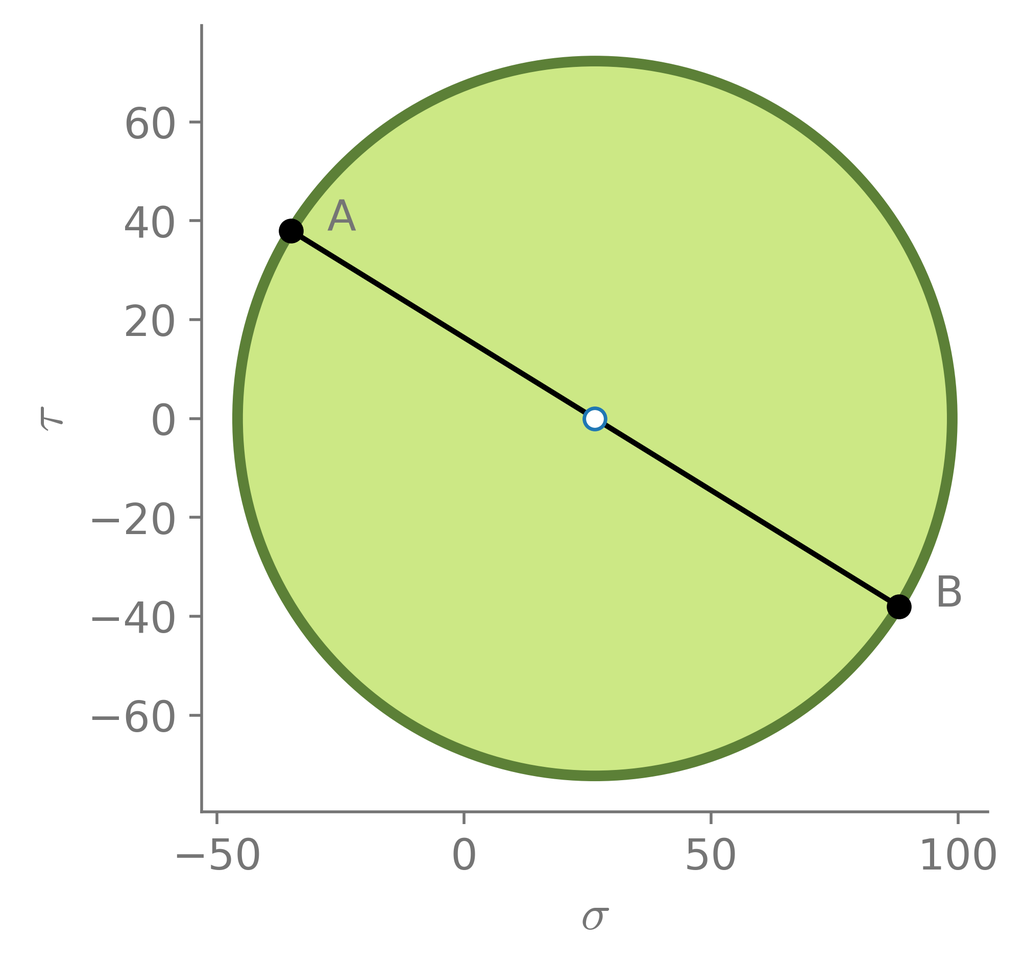

```python
print("Mohr Circle for state A")
mohr2d(St)
```

```
Mohr Circle for state B
```

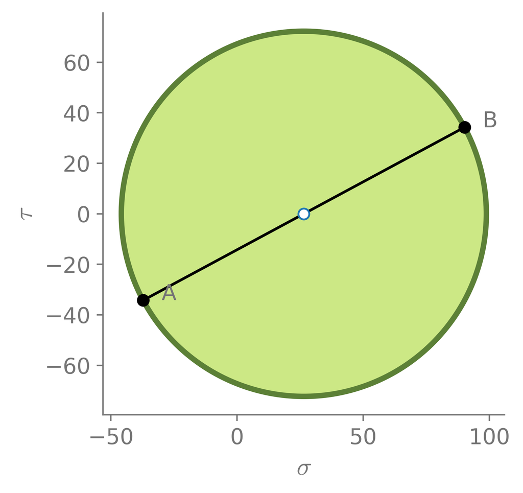

```python
print("Mohr Circle for state B")
mohr2d(St_30)
```

**Question 2:**

Consider a 2D stress state at a point in a solid, denoted as state A, with stress components given as: $\sigma_{xx}$ = 0.5, $\sigma_{yy}$= 0.5 , $\sigma_{xy}$ = -0.5, in the Cartesian coordinate system $(x, y)$.

1. Determine the principal stresses and their directions with respect to $(x, y)$ coordinate system.
2. Determine the maximum shear stress and its direction with respect to $(x, y)$ coordinate system.
3. Draw the Mohr circle.
4. Discuss about the results obtained in relation to the example given in Section 3.7.4.1.

```python
St = np.array([[0.5,-0.5],[-0.5,0.5]])

eigenvalues, eigenvectors = lg.eig(St)

#Sort in order
idx = eigenvalues.argsort()[::-1]
eigenvalues = eigenvalues[idx]
eigenvectors = eigenvectors[:,idx]
print('Pricipal stress (Eigenvalues):\n',eigenvalues,'\n')

print(f'Principal stress directions:\n{eigenvectors}\n')
```

```
Pricipal stress (Eigenvalues):
 [1. 0.]

Principal stress directions:
[[ 0.7071  0.7071]
 [-0.7071  0.7071]]
```

```python
maxshear = (np.sqrt((4*(St[0,1]**2))+((St[0,0]-St[1,1])**2)))/2

print("The maximum shear stress is %3.2f" % (maxshear))
```

```
The maximum shear stress is 0.50
```

```
Mohr Circle
```

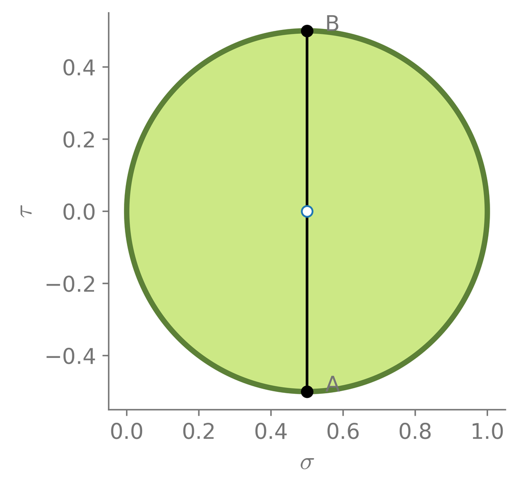

```python
print("Mohr Circle")
mohr2d(St)
```

Similar to the example, This has the the shear stress components in 45 degree rotated coordinates with respect to the Z axis. This means that this material needs to be strongest with these forces, which is consistent with the example

**Question 3:**

Consider a 3D stress state at a point in a solid with stress components given as: $\sigma_{xx}$ = 88 MPa, $\sigma_{yy}$=-35 MPa, $\sigma_{zz}$ =28 MPa, $\sigma_{xy}$ = 12 MPa, $\sigma_{xz}$= 28 MPa, and $\sigma_{yz}$= 15 MPa.

```python
St3d = np.array([[88,12,28],[12,-35,15],[28,15,28]])
Normal = np.array([2,3,0.5])

S_N, S_NN, S_NS = gr.stressOnN(St3d,Normal)

print("The stress vector on a plane with a normal vector "+str(Normal)+" is")
print(S_N)
```

```
The stress vector on a plane with a normal vector [2.  3.  0.5] is
[ 62.087  -20.192   31.5929]
```

```python
eigenvalues, eigenvectors = gr.principalS(St3d)
```

```
Pricipal stress (Eigenvalues):
 [101.0935  18.5646 -38.6581]

Principal stress directions:
[[ 0.9181  0.3933 -0.0485]
 [ 0.1225 -0.1652  0.9786]
 [ 0.3768 -0.9045 -0.1998]]

Possible angles (n1,x)=23.3444338655797∘ or 156.6555661344203∘
```

```python
def principalS_ypr(St):
    '''Diagonalization of a stress tensor in 3D, through cooridinate
    transformation via Yaw, Pitch and Roll.
    Input: St: Stress tensor, array like, 3 by 3
    return: 𝜃, 𝛽, 𝛾: Yaw, Pitch and Roll angles, in rad.
            TS_ypr: Diagonalized stress matrix array like, 3 by 3
    '''
    from scipy.optimize import fsolve

    𝜃, 𝛽, 𝛾 = symbols("𝜃, 𝛽, 𝛾")  # Angles for  Yaw, Pitch and Roll

    # Create the matrices for Yaw, Pitch, and Roll for transformations:
    Tz = gr.transf_YPRs(𝜃, about = 'z')[0]
    Ty = gr.transf_YPRs(𝛽, about = 'y')[0]
    Tx = gr.transf_YPRs(𝛾, about = 'x')[0]
    #print(f'Ty=, {Ty}, \nTx=, {Tx}, \nTz=, {Tz}')

    # Construct the tansformation matrix for Yaw, Pitch and Roll.
    T_ypr = Tz@Ty@Tx

    # Perform coordinate transformation to the given stress tensor.
    S_ypr = T_ypr@St@T_ypr.T

    # Create these three equations:
    eqns = lambda x: [S_ypr[0,1].subs({𝜃:x[0], 𝛽:x[1], 𝛾:x[2]}),
                      S_ypr[0,2].subs({𝜃:x[0], 𝛽:x[1], 𝛾:x[2]}),
                      S_ypr[1,2].subs({𝜃:x[0], 𝛽:x[1], 𝛾:x[2]})]

    # Give an initial guess randomly:
    init_guess = np.random.randn(3)/999.               # make it small

    # Solve the set of three equations numerically:
    sln = fsolve(eqns, init_guess)
    print(f'Solution, 𝜃, 𝛽, 𝛾 = {sln} (rad)')
    print(f'Solution, 𝜃, 𝛽, 𝛾 = {sln*180/np.pi} (degree)')

    # Finally, we can check the results, use 𝜃, 𝛽, 𝛾  found to
    # perform coordinate trans formation:
    T_ypr_ = T_ypr.subs({𝜃:sln[0], 𝛽:sln[1], 𝛾:sln[2]})
    S_ypr_ = T_ypr_@St@T_ypr_.T

    return 𝜃, 𝛽, 𝛾, S_ypr_
```

```python
theta, beta, gamma, S_ypr_ = principalS_ypr(St3d)
```

```
Solution, 𝜃, 𝛽, 𝛾 = [ 0.0528 -0.4042 -0.1806] (rad)
Solution, 𝜃, 𝛽, 𝛾 = [  3.0264 -23.1583 -10.3496] (degree)
```

```python
sigma_oct, tau_oct = gr.Oct_stress(eigenvalues)

print("The Octahedral shear stress:")
print(sigma_oct)
```

[output not shown]

```python
vonMises = gr.von_Mises(eigenvalues)

print("The von Mises stress:")
print(vonMises)
```

```
The von Mises stress:
121.68812596141007
```

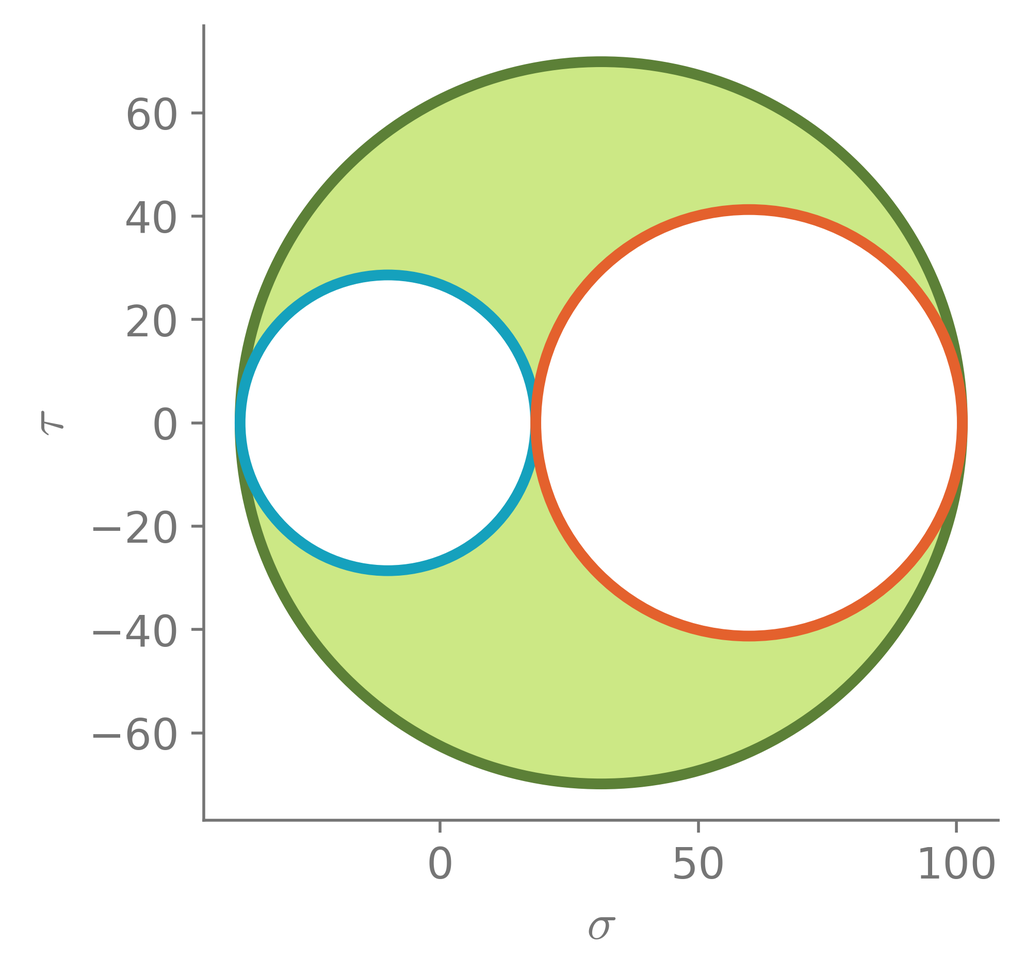

```python
mohr3d(St3d)
```